# Random number generation

## Random number generators

Random number generators (RNGs) are devices or programs that produce unpredictable and unbiased sequences of numbers.

## Why generate random numbers?

Random numbers can be used to:

- simulate different outcomes of an experiment
- generate secure keys to encrypt and decrypt data
- model different market scenarios, estimating the probability of occurrence of specific outcomes

## How can random numbers be generated?

- **hardware-based random number generators** (also known as **True Random Number Generators** or TRNGs) - *use physical phenomena such as thermal noise, radioactive decay, or quantum effects to generate random numbers*
- **software-based generators** (also known as **pseudorandom number generators** or PRNGs) - *algorithms that rely on mathematical equations to generate a sequence of numbers*

| **Feature** | **Software-Based RNG** | **Hardware-Based RNG** |
| --- | --- | --- |
| **Randomness** | Pseudorandom (deterministic) | Truly random (physical process) |
| **Speed** | Fast | Slower |
| **Cost** | Low (software only) | High (requires special hardware) |
| **Reproducibility** | Yes, given the same seed | No (true randomness) |
| **Use Case** | General use, simulations, games | Cryptography, secure key generation, highly sensitive applications |
| **Security** | Vulnerable to predictability | Highly secure (no predictable pattern) |

## Good generators

A working definition of randomness in the context of computer-generated sequences is the following:

*Any two different random number generators ought to produce statistically the same results when coupled to your particular applications program. If they don’t, then at least one of them is not a good generator.*

## The random modules

There are several methods implemented in different languages to generate random numbers:

- RandomNumberGenerator class in C++ - provides many functions for generating random values, providing also various distributions such as normal, exponential, gamma
- NativeCrypto library in Android and iOS - provides cryptographically secure random values
- the TrueRandom Arduino library - create random numbers using external sources such atmospheric noise, or internal sources like ADC readings

Among the standard python libraries, we have access to 3 set of random functions generation:

- random
- numpy.random
- scipy.stats

## Random numbers and seeds

```python
import random

random.random()
```

```
0.4052557655746465
```

```python
[random.random() for i in range(3)]
```

```
[0.4474912160726868, 0.9768692106990741, 0.2608579673292103]
```

```python
[random.random() for i in range(3)]
```

```
[0.7224470978607844, 0.5018447545520036, 0.40061001421039366]
```

```python
random.seed(42)
[random.random() for i in range(3)]
```

```
[0.6394267984578837, 0.025010755222666936, 0.27502931836911926]
```

```python
random.seed(42)
[random.random() for i in range(3)]
```

```
[0.6394267984578837, 0.025010755222666936, 0.27502931836911926]
```

## The linear congruential generator

A very simple way of generating random numbers (not a good one, but a good example) is the following:

$R_{n+1}= (a \cdot R_{n}+c)$ mod $m$

where $a$ is a positive integer called the multiplier, and $c$ is a nonnegative integer called the increment.

For $c \neq 0$, the above equation is called a linear congruential generator (LCG).

```python
# values from the numerical recipies
m = 2**32
a = 1664525
c = 1013904223
```

```python
R0 = 4
R1 = (a*R0+c)%m
R1
```

```
1020562323
```

```python
for i in range(5):
    print(R1/m)
    R1 = (a*R1+c)%m
```

```
0.2376181825529784
0.6413819692097604
0.5583668493200094
0.8159323614090681
0.04994240193627775
```

```python
results = []
for i in range(5000):
    results.append(R1/m)
    R1 = (a*R1+c)%m
```

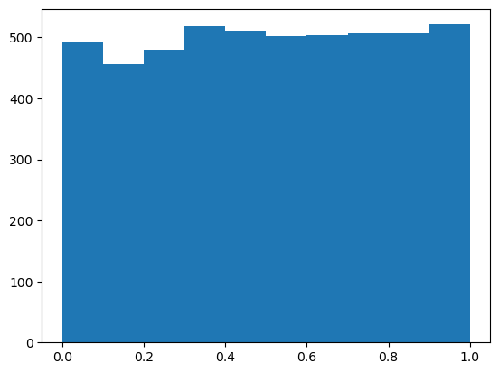

```python
import matplotlib.pyplot as plt

plt.hist(results)
plt.show()
```

## Weakness of LCGs

If $k$ random numbers at a time are used to plot points in $k$-dimensional space (with each coordinate between 0 and 1), then the points will not tend to “fill up” the $k$-dimensional space, but rather will lie on $(k-1)$-dimensional “planes”. There will be at most about $m^{1/k}$ such planes. If the constants $m$ and $a$ are not very carefully chosen, there will be many fewer than that.

## Monte Carlo method

If a method uses **random numbers** (stochastic processes) to solve a problem, it's Monte Carlo. That includes:

- Estimating integrals
- Simulating systems
- Sampling from distributions
- Calculating probabilities and related quantities

## Inverse CDF method

This is a method for generating random numbers from any probability distribution by using its inverse cumulative distribution $F^{-1}(x)$.

The cumulative distribution function (CDF) for a random variable $X$ is $F_{X}(x) = P(X \leq x)$.

### Algorithm

We want to generate a random variable $X$ with cumulative distribution function (CDF) $F_{X}$.

The algorithm is simple:

- generate a sequence of random numbers $R$ between $0$ and $1$, drawn from a uniform distribution
- find $X=F^{-1}(R)$

Let's consider the exponential distribution

$$ f(x) = \begin{cases} \lambda e^{-\lambda x} & x \geq 0, \\ 0 & x < 0. \end{cases} $$

```python
def exp_pdf(x, b=1):
    return b*np.exp(-b*x)

def exp_cdf(x, b=1):
    return 1 - np.exp(-b*x)

def exp_inv_cdf(p, b=1):
    return -np.log(1-p)/b
```

```python
import numpy as np

x = np.linspace(0,5,100)

r = np.random.random(10000)
exp_gen_r = exp_inv_cdf(r)
```

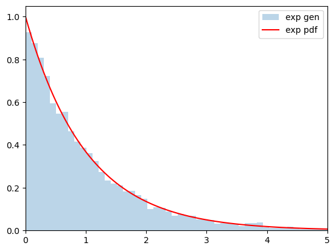

```python
plt.hist(exp_gen_r, bins=100, density=True, alpha=0.3, label='exp gen')
plt.plot(x, exp_pdf(x), 'r', label='exp pdf')
plt.xlim([0,5])
plt.legend(loc='best')
plt.show()
```

## Acceptance-rejection method

The **acceptance-rejection method** (also known as **rejection sampling**) is a technique for generating random numbers from a target probability distribution when direct sampling is difficult.

### Key idea:

- You have a target distribution, $p(x)$, from which you want to generate random samples.
- Instead of directly sampling from $p(x)$, you sample from an easier distribution, $q(x)$, and then decide whether to accept or reject that sample based on the relative likelihoods of $p(x)$ and $q(x)$.

### Algorithm:

1. **Choose a proposal distribution $q(x)$**:
   - This is a simpler distribution from which you can easily sample.
   - The key requirement is that $q(x)$ must cover the shape of $p(x)$ in the sense that $p(x) \leq M q(x)$ for all $x$, where $M$ is a constant scaling factor.
2. Generate a random number $x$, uniform in $[x_{min}, x_{max}]$
3. Generate a second independent random number $u$ uniformly distributed between 0 and $M q(x)$
4. **Check if the sample is accepted or rejected**:
   - If $u \leq p(x)$, then accept $x$. If not, reject $x$ and repeat the process (go back to step 2).
5. **Repeat the process** until you have enough valid samples.

Let's consider the following distribution in the interval $-1 \leq x \leq 1$

$$ p(x) = \frac{3}{8}(1 + x^{2}) $$

and generate numbers randomly drawn from it, using the acceptance-rejection method.

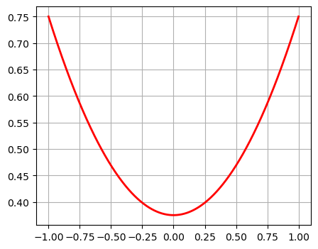

```python
def target_pdf(x):
    return (3/8) * (1 + x**2)

x = np.linspace(-1, 1, 500)
plt.figure(figsize=(5,4))
plt.plot(x, target_pdf(x), 'r-', lw=2)
plt.grid(True)
plt.show()
```

```python
def sample_using_acceptance_rejection(n_samples):
    samples = []
    while len(samples) < n_samples:
        x = np.random.uniform(-1, 1)
        u = np.random.uniform(0, 0.75)
        if u <= target_pdf(x):
            samples.append(x)
    return np.array(samples)
```

```python
# generate 10,000 samples
samples = sample_using_acceptance_rejection(10000)
```

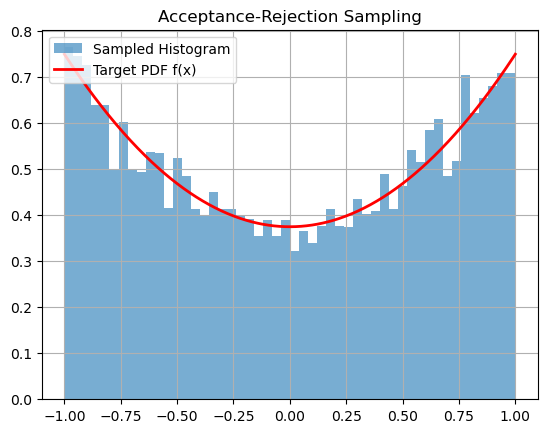

```python
# plot
x = np.linspace(-1, 1, 500)
plt.hist(samples, bins=50, density=True, alpha=0.6, label='Sampled Histogram')
plt.plot(x, target_pdf(x), 'r-', lw=2, label='Target PDF f(x)')
plt.title('Acceptance-Rejection Sampling')
plt.legend(loc='upper left')
plt.grid(True)
plt.show()
```

## Weakness of the acceptance-rejection method

The fraction of accepted points is equal to the fraction of the box’s area under the curve.

## Low-discrepancy sequences

There are better methods for exploring a function if we can, and that is by using **low-discrepancy sequences**.

These are sequences that look quite random, but do not tend to cluster as random numbers do, covering the space in a more uniform way.

The big advantage is that they keep having this property if we continue forward with the sequence of sampling.

Low-discrepancy sequences converge with $O(1/N)$, but they are a little more difficult to implement.

These methods are called quasi-Monte Carlo, as they are not using proper pseudo-random numbers.

## Van der Corput sequence

The simplest low-discrepancy sequence is the Van der Corput sequence and is quite easy to implement.

This is a way to generate numbers between 0 and 1 that are **evenly** and **efficiently** spread out.

The denominators are increasing powers of the base, the numerators are all the values in that base, but sorted based on the last digit (skipping the numbers that ends in 0, as they would simplify and recreate previous ones)

$$\left\{ \frac{1}{10}, \frac{2}{10}, \frac{3}{10},\frac{4}{10},\frac{5}{10},\frac{6}{10},\frac{7}{10},\frac{8}{10},\frac{9}{10},\frac{01}{100},\frac{11}{100},\frac{21}{100},\frac{31}{100},\frac{41}{100},\frac{51}{100},\frac{61}{100},\frac{71}{100},\frac{81}{100},\frac{91}{100},\frac{02}{100},\frac{12}{100},\frac{22}{100},\frac{32}{100},...\right\}$$

## How the sequence is built

- Pick a base - usually base 2 (binary), but you can use base 3, 10, etc.
- For a given integer *n*, write it in that base.
- Reverse the digits (not the order of bits, but reflect them across the decimal).
- Place those reversed digits after the decimal point.
- Convert to decimal form

Let's compute the first 12 values of the sequence in base 10:

| n | Digits | Reflected Fraction | Decimal Value |
| --- | --- | --- | --- |
| 0 | 0 | .0 | 0.0 |
| 1 | 1 | .1 | 0.1 |
| 2 | 2 | .2 | 0.2 |
| 3 | 3 | .3 | 0.3 |
| 4 | 4 | .4 | 0.4 |
| 5 | 5 | .5 | 0.5 |
| 6 | 6 | .6 | 0.6 |
| 7 | 7 | .7 | 0.7 |
| 8 | 8 | .8 | 0.8 |
| 9 | 9 | .9 | 0.9 |
| 10 | 1,0 | .01 | 0.01 |
| 11 | 1,1 | .11 | 0.11 |

Let’s compute the first 8 values of the sequence in base 2:

| n | Binary of n | Reflected (after decimal) | Decimal value |
| --- | --- | --- | --- |
| 0 | 0 | .0 | 0.0 |
| 1 | 1 | .1 | 0.5 |
| 2 | 10 | .01 | 0.25 |
| 3 | 11 | .11 | 0.75 |
| 4 | 100 | .001 | 0.125 |
| 5 | 101 | .101 | 0.625 |
| 6 | 110 | .011 | 0.375 |
| 7 | 111 | .111 | 0.875 |

```python
def vdc(n, base=10):
    vdc = 0
    denom = 1
    while n:
        denom *= base
        n, remainder = divmod(n, base)
        vdc += remainder / denom
    return vdc

def avdn(n, base=10):
    return np.array([vdc(i, base=base) for i in range(1, n+1)])
```

```python
avdn(11)
```

```
array([0.1 , 0.2 , 0.3 , 0.4 , 0.5 , 0.6 , 0.7 , 0.8 , 0.9 , 0.01, 0.11])
```

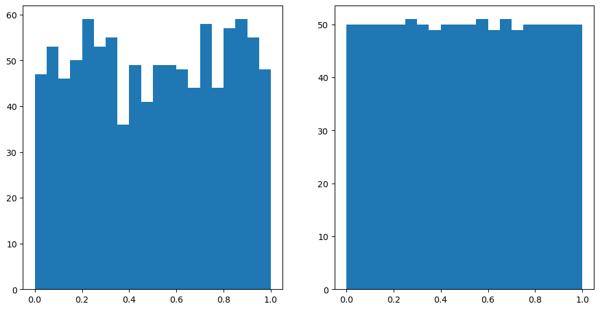

```python
import matplotlib.pyplot as plt
fig, (ax1, ax2) = plt.subplots(1, 2, figsize=(12, 6))
bins = np.linspace(0, 1, 21)
ax1.hist(np.random.rand(1000), bins=bins)
ax2.hist(avdn(1000, 10), bins=bins)
plt.show()
```

Being a uniform sample generator, one can then use this to generate arbitrary random variables.

For example, we can use it to generate normally distributed data.

To do that we can use the `isf` function from `scipy.stats` module.

```python
import scipy.stats as st
```

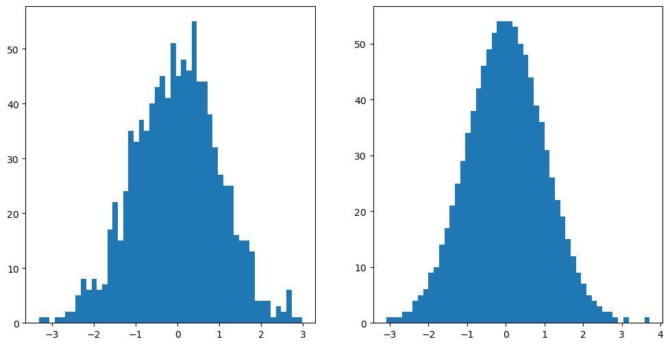

```python
fig, (ax1, ax2) = plt.subplots(1, 2, figsize=(12, 6))
ax1.hist(np.random.randn(1000), bins=50)

vdn_sample = avdn(1000)
gaussian_samples = st.norm.isf(vdn_sample)
ax2.hist(gaussian_samples, bins=50)
plt.show()
```

The Van der Corput sequence can be generalized to **multiple dimensions** at the same time by the Halton sequence, that is generated in a similar fashion.

A general library to generate these sequences in high dimensions is provided by the library `SALib`.

You won't need it for today, but for real use, where the number of dimensions is high, it might be worth using it.

# Exercise

Generate random samples drawn from the following probability density function (PDF):

$$p(x) = xe^{-x}, \quad x \geq 0$$

This is known as the Gamma distribution with shape $k=2$ and rate $\lambda=1$.

Which method would you choose and why?